# TCRBroom: an example workflow

23 March 2023

# Contents

## 1. Introduction

The `TCRBroom` package is designed to check pairwise overlap and cross-cohort overlap for TCR samples. This vignette shows a simple workflow illustrating how TCRBroom package works.

### Installation

The package can be installed using `devtools` by the following commands

```r
library(devtools)
install_github("rx-li/TCRBroom")
```

After the installation, the package can be loaded with

```r
library(TCRBroom)
```

## 2. Example workflow

The data we used in this example workflow can be found in the folder `data/`. 18 samples from 10 patients are simulated based on the real contaminated data.

First, we need to read the meta files. The meta files includes sample names and their corresponding subject ID.

```r
meta <- read.csv("../data/meta.csv")
head(meta)
```

```
#>   sample_name subject_id
#> 1    s1_1.tsv        P01
#> 2    s1_2.tsv        P01
#> 3    s1_3.tsv        P01
#> 4    s1_4.tsv        P01
#> 5    s2_1.tsv        P02
#> 6    s2_2.tsv        P02
```

Then, we can check the pairwise overlap using the following command.

```r
pairwise_table <- checkPairwise(meta, "../data/")
```

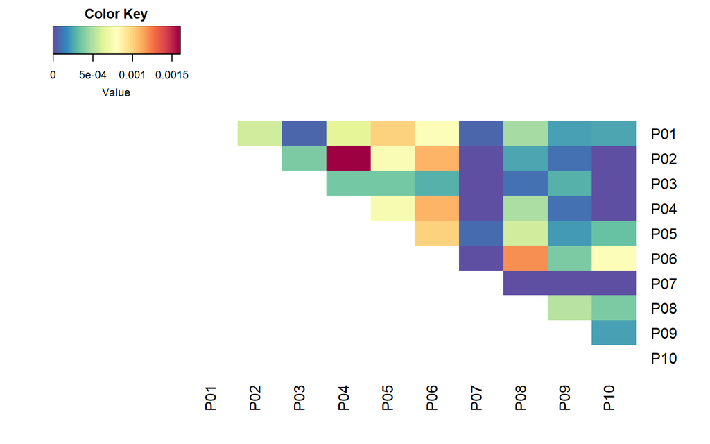

The heatmap shows the magnitude of the pairwise overlaps. A matrix is also created for users to check the values of the overlaps:

```r
pairwise_table[1:3, 1:3]
```

```
#>     P01     P02     P03
#> P01  NA 0.00058 7.1e-05
#> P02  NA      NA 3.7e-04
#> P03  NA      NA      NA
```

We can also call the function to check the cross-cohort overlap (sequence prevalence).

```r
crosscohort_table <- checkCrosscohort(meta, "../data/", seq.n=30)
```

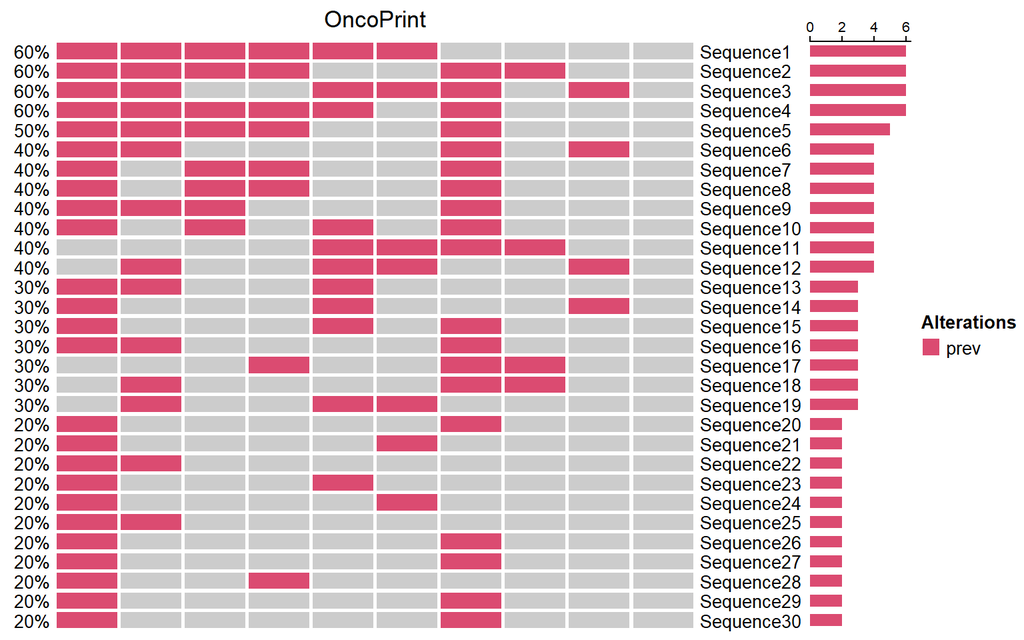

By default, the function will generate an OncoPrint showing prevalence for the 30 most prevalent sequences.

If users would like to identify the subjects with relatively fewer sequences (such as subjects with less than 3000 sequences), `ssampleIndicator` can generate a table to note those subjects.

```r
seq_summary <- ssampleIndicator(meta, "../data/", low.seq=3000)
head(seq_summary)
```

```
#>   subject_id n_unique_seq low_seq
#> 1        P01        10388    <NA>
#> 2        P02         1791   Alert
#> 3        P03         3620    <NA>
#> 4        P04         1864   Alert
#> 5        P05         7416    <NA>
#> 6        P06         3640    <NA>
```

Subjects with sequences fewer than 3,000 will be noted as “Alert” in the “low_seq” column.